# Exploratory Data Analysis of GeoCovid 19 Data on Feb 01

Rafi Trad

2020-08-19

# Exploration and Preprocessing of Twitter Data

```r
library(dplyr)
library(readr)
library(stringr)
library(poweRlaw)
library(tm)
library(wordcloud)
library(textclean)
library(cowplot)

twitter_data <- read_csv("../../../Datasets/twitter-sars-cov-2/ids_all_langs__2020-02-01/ids_2020-02-01.csv")
```

Through [GeoCov19](https://crisisnlp.qcri.org/covid19), SARS-COV-2 related tweets on February the 1st, 2020 were elicited via Twitter APIs. The shape of data is [519654, 34]. Within the data there are 322951 users (authors) who (re)tweeted these 519654 tweets. However, we want users who wrote original tweets, not simply re-tweeted them. For that, we will filter out the pure re-tweets.

```r
twitter_data = twitter_data %>% filter(is.na(reweet_id))
```

After selecting only the root tweets, we end up with 97561 original tweets and a clusteriness ratio $k/N$ of 0.6806408. Judging from the clusteriness ratio, it is still desirable to have bigger clusters; the expected average cluster size at this rate is 1.4692037. Let’s have a look at the users who tweeted at least 5 Covid-related tweets:

```r
# Taking only the users who tweeted 5 times at least
frequent_tweeters =
  twitter_data %>%
  count(user_screen_name, sort = TRUE, name="tweet_counts") %>%
  filter(tweet_counts >= 5)
# Only preserve the users who have 5 or more original tweets
twitter_data = twitter_data %>%
  filter(twitter_data$user_screen_name %in% frequent_tweeters$user_screen_name)
```

We find that there are 1973 of them, and the ordered frequency of their tweets can be depicted thus:

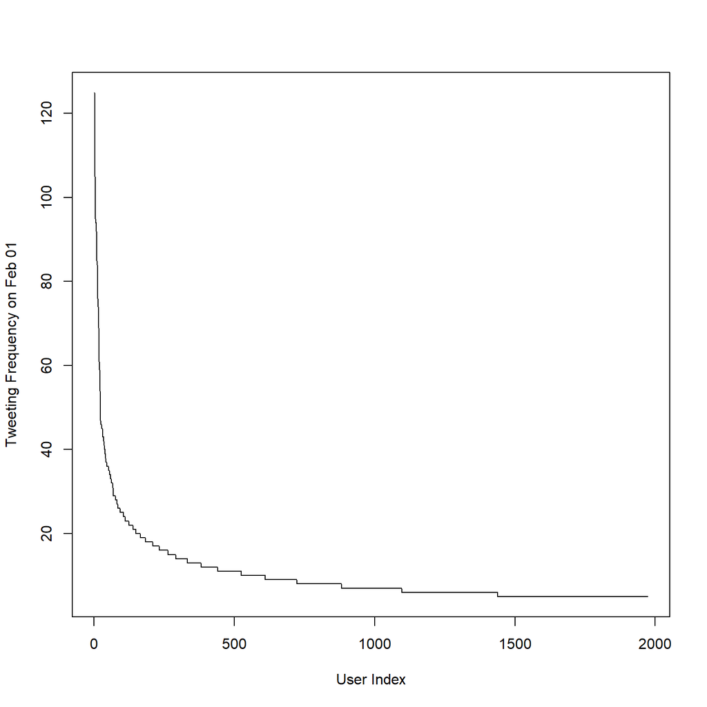

```r
plot(frequent_tweeters$tweet_counts, type="l",
     ylab = "Tweeting Frequency on Feb 01", xlab = "User Index")
```

If you look at the geographical attributes, we have a general place associated with tweets besides accurate coordinates. Firstly we’ll shine a light on how many tweets are tagged with a place:

```r
twitter_data = twitter_data %>% mutate(placetagged = !is.na(twitter_data$place))
summary(twitter_data$placetagged)[2:3]
```

```
## FALSE  TRUE
## 19830   299
```

Let’s detect how many tweets are geo-tagged:

```r
twitter_data = twitter_data %>%
  mutate(geotagged = !is.na(twitter_data$coordinates))
summary(twitter_data$geotagged)[2:3]
```

```
## FALSE  TRUE
## 20113    16
```

This indicates that there are 299 tweets out of 20129 associated with a place . Furthermore, the number of tweets which include geographical coordinates are 16 out of 20129.

## Re-tweets Analysis

As we see next, the re-tweet counts per original tweets are extremely skewed and imbalanced in general:

```r
summary(twitter_data$retweet_count)
```

```
##     Min.  1st Qu.   Median     Mean  3rd Qu.     Max.
##    0.000    0.000    0.000    5.749    1.000 2855.000
```

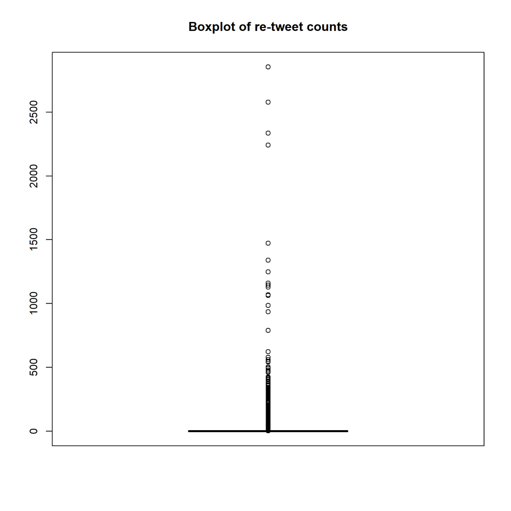

```r
boxplot(twitter_data$retweet_count, main = "Boxplot of re-tweet counts")
```

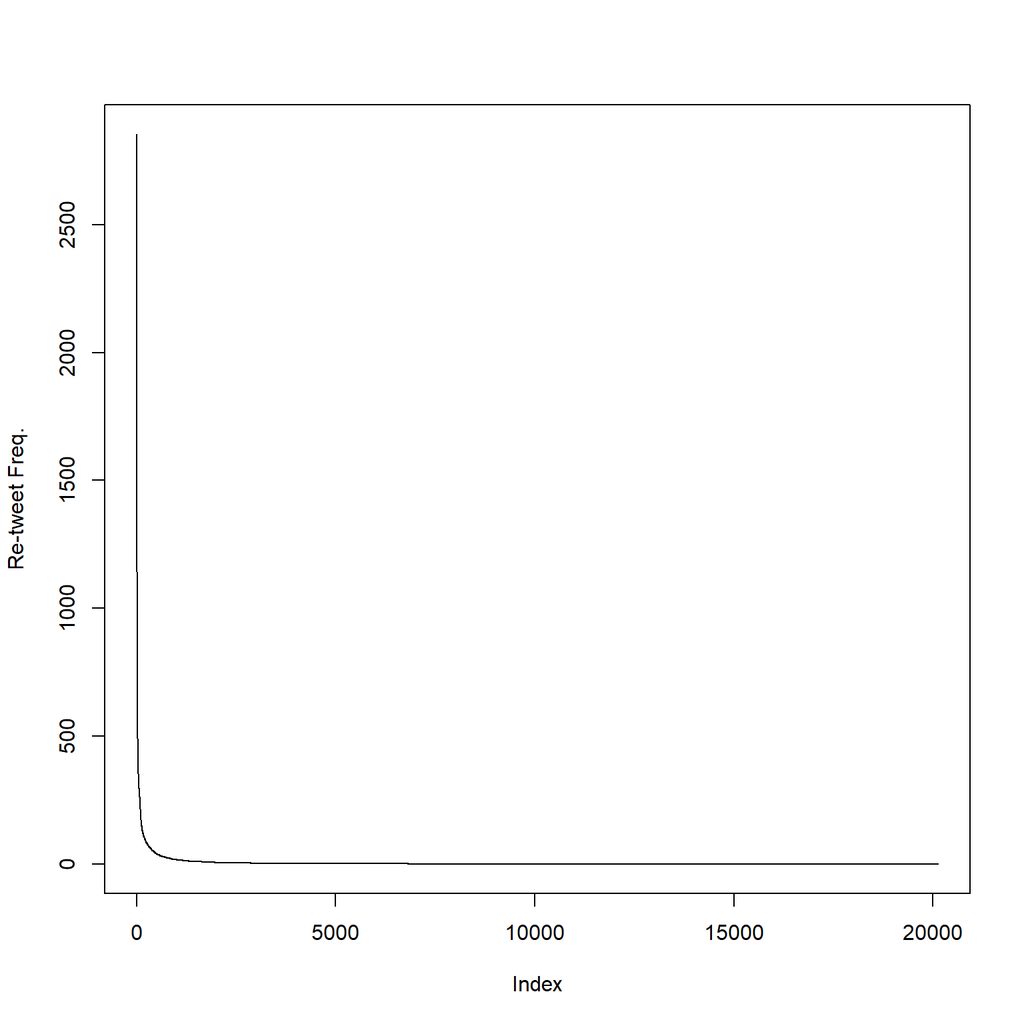

```r
plot(sort(twitter_data$retweet_count, decreasing = TRUE), type = 'l', ylab = "Re-tweet Freq.")
```

Next we will group the re-tweets by author/tweeter and examine the data trends:

```r
tweets_by_user = twitter_data %>% group_by(user_screen_name) %>% summarise(freq = sum(retweet_count)) %>% arrange(desc(freq))
summary(tweets_by_user$freq)
```

```
##    Min. 1st Qu.  Median    Mean 3rd Qu.    Max.
##    0.00    0.00    3.00   58.65   14.00 4727.00
```

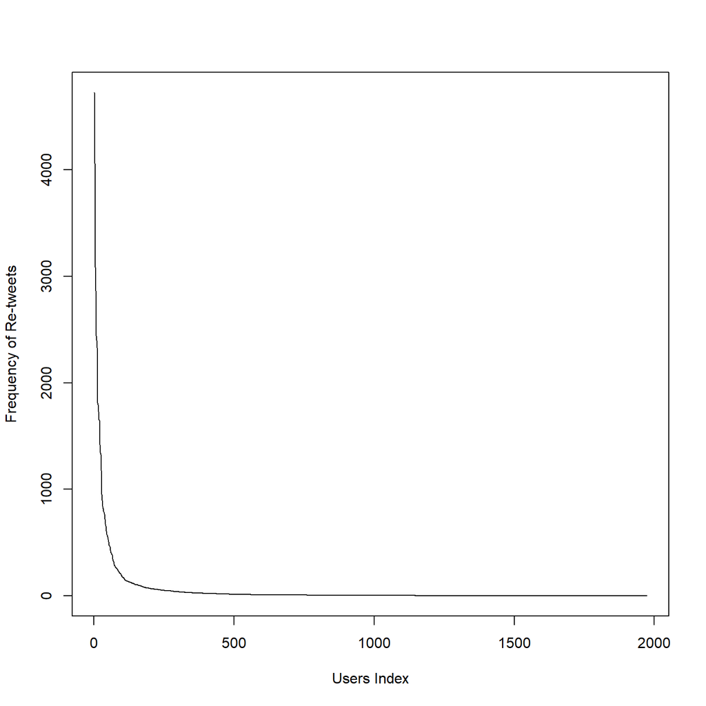

```r
plot(tweets_by_user$freq, type="l", xlab = "Users Index", ylab = "Frequency of Re-tweets")
```

## Hashtags analysis

As the tweets are harvested using not only hashtags but also keywords, some of the tweets were not tagged with hash-tags.

```r
# Number of tagged tweets
tagged_count = twitter_data %>% filter(!is.na(hashtags)) %>% count %>% unlist
```

However, hashtags can provide valuable insights into the topic words to which the tweets are linked, consequently let’s have a look at the top hashtags used by the 11739 tweets:

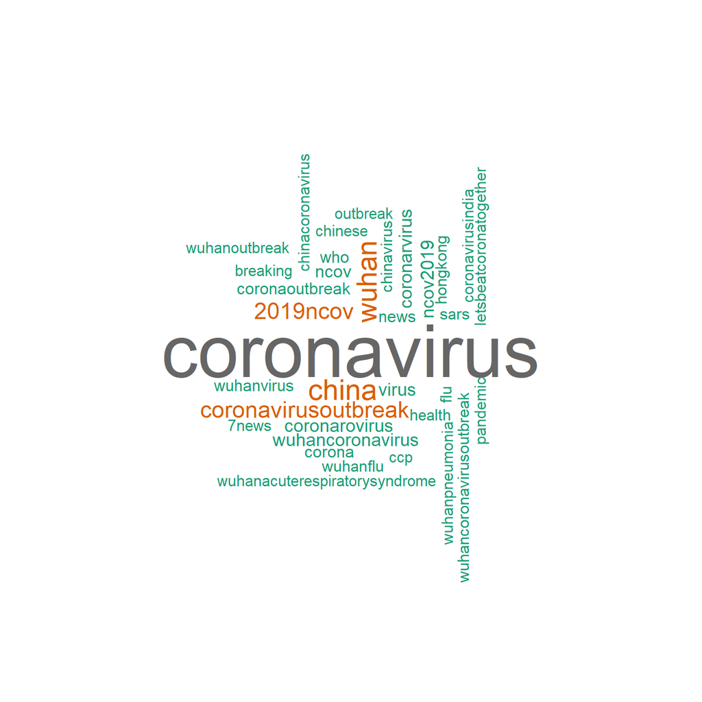

```r
tf = termFreq(doc = paste0(twitter_data$hashtags, collapse = " "),
        control = list(tolower = TRUE))

wordcloud(words = names(tf), freq = as.vector(tf), min.freq = 100,
          max.words=50, random.order=FALSE, rot.per=0.35,
          colors=brewer.pal(8, "Dark2"), scale = c(5,1))
```

# Power-Law Analysis of Tweet Counts

One pressing question is: do we have an underlying power-law distribution? This is likely, as we expect to find that the social media data follow Zipf’s distribution. It is tricky, however, to prove this, since power-law can fit any data, so let’s use an analytical solution in line with Clauset et al. A hypothesis test is performed with H0 being that the power-law fit is a good fit, and if $p < 0.1$, then we can reject the power-law hypothesis and conclude that it is not a good fit to our data, hence no power-law.

Fitting a (discrete) power-law distribution to the data gives us the red line in the following logarithmic figure:

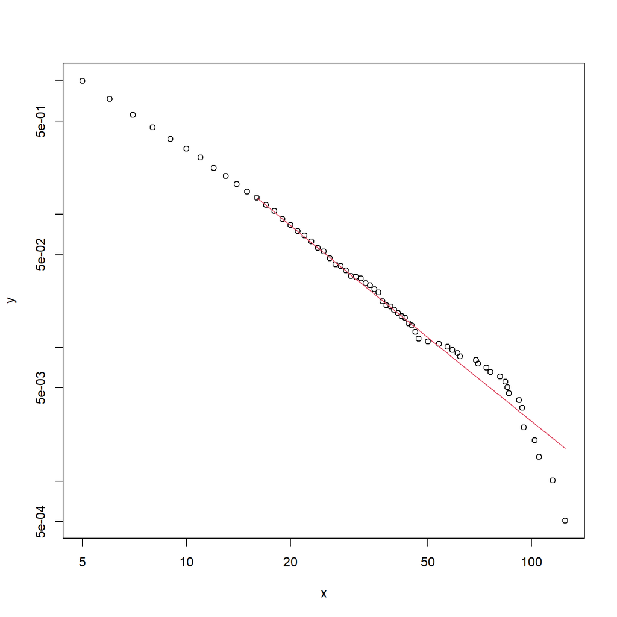

```r
# Do we want to use the precompiled p-values to save time?
use_precomputed_p_vals = TRUE
object_pl = displ$new(frequent_tweeters$tweet_counts)
object_pl$setXmin(estimate_xmin(object_pl))
# There is no need to run the following line as parameters shall be estimated conditionally on xmin
# object_frequesnt_tweeters$setPars(estimate_pars(object_frequesnt_tweeters))
# Get the parameters
xmin = object_pl$getXmin()
alpha = object_pl$getPars()
# Plotting
plot(object_pl)
lines(object_pl, col = 2)
```

The figure is not quite linear, and the estimated parameters are $x_{min} = 16$ and $\alpha = 3.0746545$; so:
$$y = Cx^{-3.0746545}: x > 16$$

When testing the power-law hypothesis, we use a number of synthetic tests, and in each one we generate a synthetic true power-law distribution with the parameters $x_{min} = 16 \wedge \alpha = 3.0746545$. Upon that, KS distances from or data are calculated and we see how many times we score a similarity, which can indicate the percentage of times our data are similar to a true power-law one with the same parameters, and thus we calculate the p-value.

```r
# Calucated spearately due to time
if (use_precomputed_p_vals)
{
    # Since it takes a lot of time, I did the calculation once and here is the value
  pval = 0.67
} else {
  bs_p = bootstrap_p(object_frequesnt_tweeters, no_of_sims = 2500, threads = 4)
  pval = bs_p$p
}
```

Executing this procedure with 2500 tests (to guarantee the the resultant p-value is accurate to 2 decimal digits as per Caluset et al.), we find that $p = 0.67$, which means that the power-law hypothesis **was not rejected**.

Knowing that power-law is a good fit doesn’t mean it’s the best fit, and for that, we shall compare it to the two most prominent competing distributions: the *lognormal* and *exponential* distributions.

## Power-Law vs. Lognormal vs. Exponential

In a similar fashion to how we tested for power-law, we will test for lognormal and exponential. The goal is determining whether power-law is the “best” fit or not.

### Exponential Fit

```r
object_exp = disexp$new(frequent_tweeters$tweet_counts)
object_exp$setXmin(estimate_xmin(object_exp))
exp_xmin = object_exp$getXmin()
exp_lambda = object_exp$getPars()

# Calucated spearately due to time
if (use_precomputed_p_vals)
{
  exp_p = 0.0012
} else {
  # Perform the tests and find the p-value for the lognormal distribution
  exp_bs_p = bootstrap_p(object_exp, no_of_sims = 2500, threads = 4)
  exp_p = exp_bs_p$p
}
```

Fitting the exponential distributions gives us the parameters: $x_{min} = 26 \wedge \lambda = 0.0500715$. We perform 2500 tests to assess whether it is a good fit, and we end up with $p = 0.0012$. This indicates that H0 (that the data is likely to be sampled from exponential distributions) **could be rejected**, and hence the exponential distribution being a possibility is out of the question.

### Lognormal Fit

```r
object_lognormal = dislnorm$new(frequent_tweeters$tweet_counts)
object_lognormal$setXmin(estimate_xmin(object_lognormal))
ln_xmin = object_lognormal$getXmin()
ln_mu = object_lognormal$getPars()[1]
ln_ss = object_lognormal$getPars()[2]
if (use_precomputed_p_vals)
{
  ln_p = 0.6324
} else {
  # Perform the tests and find the p-value for the lognormal distribution
  ln_bs_p = bootstrap_p(object_lognormal, no_of_sims = 2500, threads = 4)
  ln_p = ln_bs_p$p
}
```

Fitting the lognormal distributions gives us the parameters: $x_{min} = 7 \wedge \mu = -0.7242137 \wedge \sigma^2 = 1.4649295$. We perform 2500 tests to assess whether it is a good fit, and we end up with $p = 0.6324$. This indicates that H0 (that the data is likely to be from lognormal distributions) **could not be rejected**.

### Direct comparisons

As shown above, power-law is a good fit of the selected twitter data. While an exponential distribution is found to be not a good fit, and thus ruled out, a lognormal distribution can describe the data as good as or even better than the power-law distribution. This marks the need for additional direct comparisons between power-law and lognormal.

To compare these two distributions, we need to unify $x_{min}$, and to this end, we will set it to be the maximum between the two fits and re-estimate the parameters where necessary. Our power-law fit uses $x_{min} = 16$ while the lognormal fit picks $x_{min} = 7$; this leaves us with $x_{min} = 16$ as a unification, and so we need to re-estimate the lognormal parameters.

```r
object_lognormal$setXmin(xmin)
object_lognormal$setPars(estimate_pars(object_lognormal))
ln_mu = object_lognormal$getPars()[1]
ln_ss = object_lognormal$getPars()[2]
```

At $x_{min} = 16$, the estimated lognormal parameters are $\mu = -3.0212782 \wedge \sigma^2 = 1.7940911$. Now that we unified the lower data threshold and updated the models where necessary, we can proceed in directly comparing them using a two-sided test with these two hypotheses:

- H0: Both distributions are equally far from the true distribution
- H1: One of the test distributions is closer to the true distribution

```r
comp = compare_distributions(object_pl, object_lognormal)
```

The result indicates that the two sided p-value is 0.4977891 and the corresponding test statistic is -0.6779726, and **H0 is not rejected**.

## Conclusion

Both of power-law and lognormal distributions perform equally well in fitting our heavy-tailed twitter data, where we prune away re-tweets and select users who tweeted five times at least. As a culmination, we provide a visual inspection of the two fits goodness-of-fit (log-log) plot below, where the power-law trajectory is superimposed in a solid black line, and the lognormal one is dashed and red.

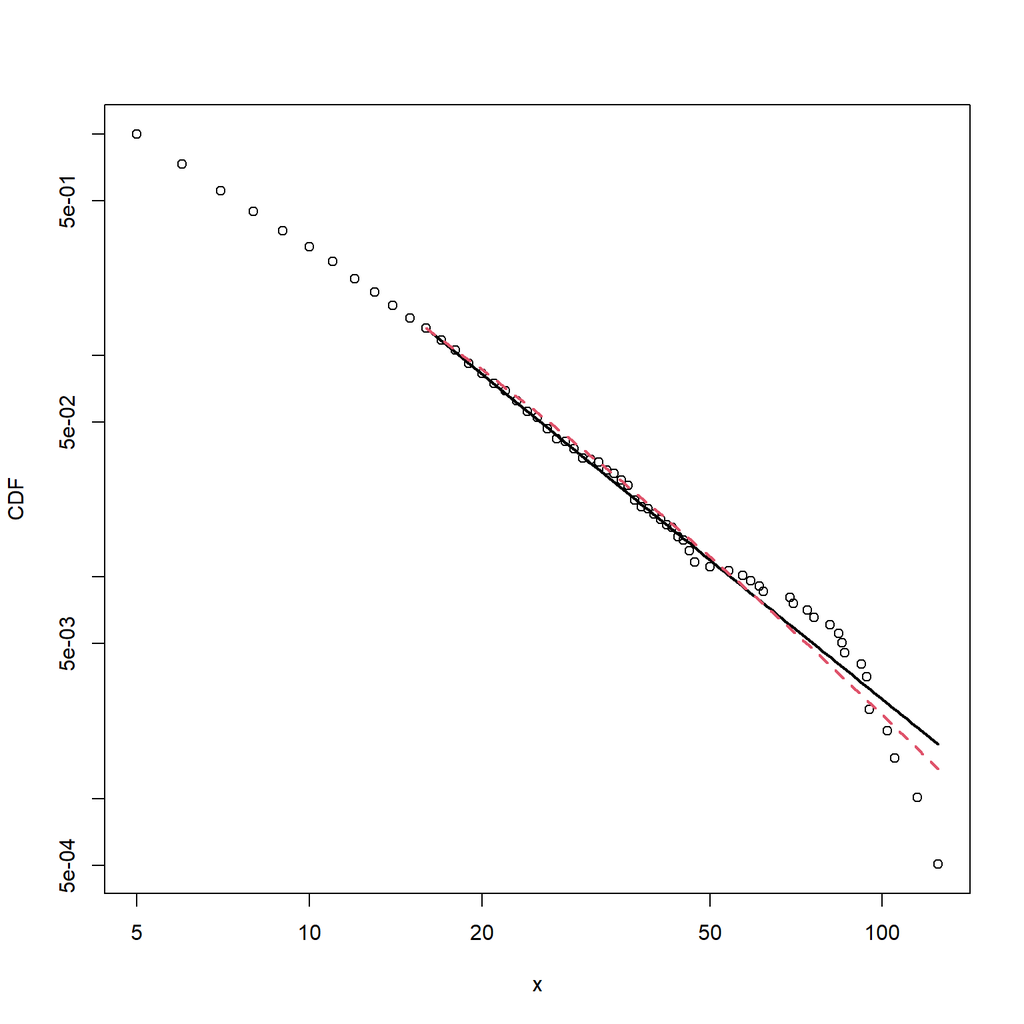

```r
plot(object_pl, ylab = "CDF")
lines(object_pl, lwd = 2)
lines(object_lognormal, col = 2, lty = 2, lwd = 2)
```

# Data Cleaning and Preparation

Firstly, we need to construct the suitable data object for further more advanced text mining and general data cleaning, comprising lower-casing and stripping excessive white spaces.

The domain-dependant data cleaning process consists of two main steps: * Cleaning the tweets from the hash-tags and the hyper-links, as these do not contribute to the writing styles of users * Removing too infrequent words as a preprocessing variant

As to the included hyper-links in a tweet, `urls` attribute can be utilised towards removing them.

We can find the hash-tags associated with each tweet via the `hashtags` attribute, so we can identify what hash-tags to remove via the following code snippet:

```r
# Make an augmented corpus with the relevant attribute and metadata
# We need a specific order and naming of columns
tagged_data = twitter_data %>% select(id, text, user_screen_name) %>% rename(doc_id = id)
# Make the tm corpus thereof
Coprus = VCorpus(DataframeSource(tagged_data))
# Now we can apply the cleaning functions to remove the hashtags and hyperlinks from tweets
Corpus = tm_map(x = Coprus, FUN = content_transformer(replace_hash))
Corpus = tm_map(x = Corpus, FUN = content_transformer(replace_url))
```